# macrotopicsA_chapter2_4

```python
class Models:
    def __init__(self,β:float,γ:float,rent:float,nw:int,w_max:float,w_min:float,grid_w:"np.ndarray[np.float64]"):
        # パラメータ
        self.β = β # 割引因子
        self.γ = γ # 相対的危険回避度

        # 要素価格
        self.rent = rent # 純利子率

        # グリッド
        self.nw = nw # 所得グリッドの数
        self.w_max = w_max # 所得グリッドの最大値
        self.w_min = w_min # 所得グリッドの最小値
        self.grid_w = grid_w # 所得グリッド
```

```python
def Calibration():
    # パラメータはここで設定をする
    β = 0.985**30
    γ = 2.0
    rent = 1.025**30 - 1.0
    nw = 10
    w_max = 1.0
    w_min = 0.1

    grid_w = np.linspace(w_min,w_max,nw)

    return Models(β, γ, rent, nw, w_max, w_min, grid_w)
```

```python
def mu_CRRA(cons,γ):
    return cons**(-γ)
```

```python
# 使う関数を呼び出す
import numpy as np # 配列を扱うためのパッケージ
import matplotlib.pyplot as plt # プロットを行うためのパッケージ
# !pip install japanize_matplotlib
import japanize_matplotlib # プロットで日本語を使うためのパッケージ
from scipy import optimize # Python上の Optimization Tool
import time # 計測時間をはかるためのパッケージ
```

## 射影法

- 最適化と求根アルゴリズムを使った手法は、現在の資産水準を離散個に区切って、そのうえでの最適貯蓄を計算するという点で共通している
- それに対して射影法(projection method)では、政策関数全体を近似する
- 例えば、貯蓄関数を$N$次の多項式(polynomials)

$$ \hat{g}(w;\mathbb{\theta}) = \sum_{n=0}^{N} \theta_{n}w^{n} \tag{9} $$

で近似したいとしよう

- (4)式から、$a=\theta_{1}w$の形式で表現できることがここでは分かっている
- しかし、一般的には政策関数はより複雑な形状をしている
- 射影法は、オイラー方程式を満たす政策関数を探すという問題を、多項式における未知の係数ベクトル$\mathbb{\theta}=\{\theta_{n}\}_{n=0}^{N}$を探す問題に置き換える
- より一般的には、多項式は

$$ \hat{g}(w;\mathbb{\theta}) = \sum_{n=0}^{N} \theta_{n}\Psi_{n}(w) $$

と書くことが出来る。このとき、$\Psi_{n}(w)$は基底関数(basis function)と呼ばれる。

- (9)式が真の政策関数をうまく近似しているのであれば、この式を(8)式の残差関数に代入した場合の残差はゼロに近いはずである。すなわち、

$$ R(w;\mathbb{\theta}) = \beta(1+r) \frac{u'((1+r)\hat{g}(w;\mathbb{\theta}))}{u'(w-\hat{g}(w;\mathbb{\theta}))} -1 = 0 $$

が「あらゆる$w$」で成立している必要がある

- 実際には、$R(w;\mathbb{\theta})$が「十分に」ゼロに近ければよい
- 距離関数$\rho$(metric fuction)を導入すると、政策関数を探す問題は、

$$ \hat{\mathbb{\theta}} = \text{arg}\min_{\theta}\rho(R(w;\mathbb{\theta}),0) $$

を探す問題に置き換えることができる

- ここでは任意の評価点を取って、そこでの残差（の絶対値）がゼロに近くなる係数ベクトル$\theta$を探す。これを選点法(collocation method)と呼ぶ
- アルゴリズム
1. パラメータを設定する（カリブレーション）。
2. 選点(collocation)$w_{i}\in\{w_{1},\dots,w_{I}\}$を定める。今回はこれまでと同じく$w_{i} \in \{0.1,0.2,0.3,\dots,1.0\}$とする。
3. 近似したい政策関数の関数形を定める。今回は1次関数$\hat{g}(w;\mathbb{\theta}) = \theta_{0} + \theta_{1}w$とする。
4. $\{\theta_{0},\theta_{1}\}$をインプットとして、選点上の残差$R(w_{i},\mathbb{\theta})$を計算して返すサブルーチンを書く。
5. *距離関数を最小化*する$\{\theta_{0}^{*},\theta_{1}^{*}\}$を見つける。
6. 得られた$\hat{g}(w;\mathbb{\theta}^{*}) = \theta_{0}^{*} + \theta_{1}^{*}w$が貯蓄関数である。

```python
def approx_policy(coef,eval):
    """
    政策関数を多項式によって近似する

    # インプット
    `coef`: 多項式の係数
    `eval`:選点

    # アウトプット
    `next_a`:2期における資産水準
    """

    dim_app = len(coef)
    nw = len(eval)
    XX = np.zeros((nw, dim_app))

    for i in range(dim_app):
        XX[:,i] = eval ** i

    next_a = XX @ coef.T

    return next_a
```

```python
def resid_projection(coef, params):
    """
    選点に基づいてオイラー方程式の残差を返す

    # インプット
    `coef`:多項式の係数
    `m::Models`:パラメータを含む構造体

    # アウトプット
    `residual::Vector`:残差
    """

    # 係数coefを使って政策関数を計算
    a = approx_policy(coef, params.grid_w)

    # 各wにおける1期の消費水準を計算
    c1 = params.grid_w - a

    # 2期の消費水準
    c2 = (1.0 + params.rent)*a

    ng = len(c1) # 次元を取り出す
    mu1 = np.zeros(ng) #1期における限界効用
    mu2 = np.zeros_like(mu1) #2期における限界効用
    resid = np.zeros_like(mu1) #残差

    for i in range(ng):

        if c1[i] > 0.0:
            mu1[i] = mu_CRRA(c1[i], params.γ)
        else:
            mu1[i] = 10000.0 #負の消費に対するペナルティ

        if c2[i] > 0.0:
            mu2[i] = mu_CRRA(c2[i], params.γ)
        else:
            mu2[i] = 10000.0 #負の消費に対するペナルティ

        resid[i] = params.β*(1.0 + params.rent)*(mu2[i]/mu1[i]) - 1.0


    return resid
```

```python
params = Calibration()

# % 係数の初期値を当て推量(initial guess)
coef_init = [0.1, 0.35]

# 多項式の次元を決定
resid_projection1 = lambda coef: resid_projection(coef, params)

# レーベンバーグ・マルカート法で非線形最小二乗法を行う
res = optimize.least_squares(resid_projection1,x0=coef_init,method="lm")

# ゼロ点探索によって得た係数を使って政策関数を求める
next_a = approx_policy(res.x, params.grid_w)

# return res.x, res.success , next_a
```

```python
# 解析解
# テキストの(2.4)式
coef1 = (params.β*(1.0+params.rent))**(-1.0/params.γ)
coef2 = 1.0/(1.0+coef1*(1.0+params.rent))
a_cfs = coef2*params.grid_w
```

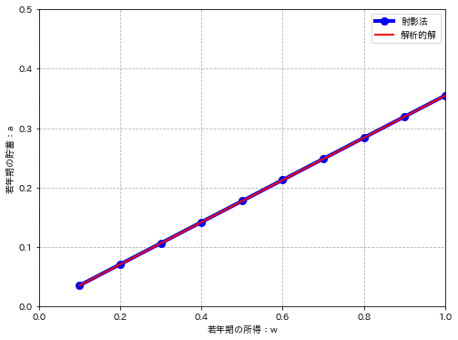

```python
fig, ax = plt.subplots(figsize=(8,6))
ax.plot(params.grid_w,next_a,c="b",marker="o",lw=4,ms=8,label="射影法")
ax.plot(params.grid_w,a_cfs,c="r",lw=2,label="解析的解")
ax.set(xlabel="若年期の所得：w",ylabel="若年期の貯蓄：a",xlim=(0,1.0),ylim=(0,0.5))
ax.legend(loc="upper right")
ax.grid(ls="--")
plt.show()
```